# 01-Simple models - disturbance index

Francisco E. Fonturbel

26/mar/2022

## Anthropogenic effects on chungungo’s abundance

Here we will explore some anthropogenic variables as potential drivers of abundance change on this species

Let’s do some nice ggplots to examine our data before fitting fancy models:

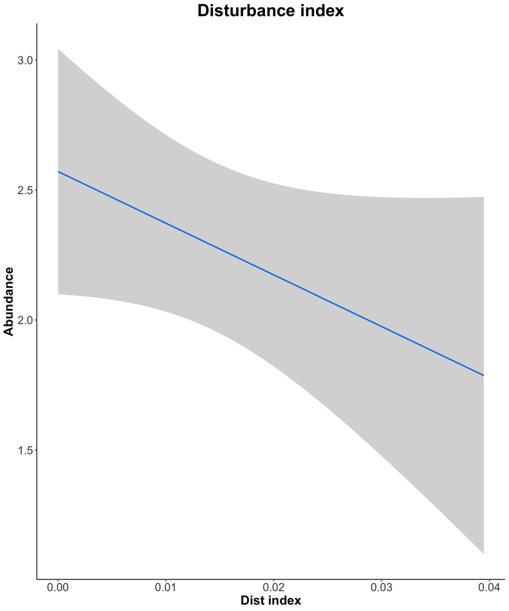

There is a trend but the error is HUGE!

## Models

To do this, we will use a simple GLMM, using site and sampling month as random factors.

```
## Linear mixed model fit by REML. t-tests use Kenward-Roger's method [
## lmerModLmerTest]
## Formula: abund ~ distindx + (1 | site) + (1 | month)
##
## REML criterion at convergence: 204.8
##
## Scaled residuals:
##     Min      1Q  Median      3Q     Max
## -2.3623 -0.4835 -0.1121  0.5212  3.6749
##
## Random effects:
##  Groups   Name        Variance Std.Dev.
##  month    (Intercept) 0.0000   0.0000
##  site     (Intercept) 1.1652   1.0794
##  Residual             0.9818   0.9909
## Number of obs: 70, groups:  month, 12; site, 6
##
## Fixed effects:
##             Estimate Std. Error      df t value Pr(>|t|)
## (Intercept)   2.2635     0.4813  5.9256   4.702  0.00343 **
## distindx      1.3519    10.9472 59.5770   0.123  0.90214
## ---
## Signif. codes:  0 '***' 0.001 '**' 0.01 '*' 0.05 '.' 0.1 ' ' 1
##
## Correlation of Fixed Effects:
##          (Intr)
## distindx -0.302
## optimizer (nloptwrap) convergence code: 0 (OK)
## boundary (singular) fit: see ?isSingular
```

Following Ben Bolker’s advice, we can avoid singular fit by removing those random effects with a very litle contribution (in this case, *month*). Let’s try fitting a new model using only *site* as random effect:

```
## Linear mixed model fit by REML. t-tests use Kenward-Roger's method [
## lmerModLmerTest]
## Formula: abund ~ distindx + (1 | site)
##
## REML criterion at convergence: 204.8
##
## Scaled residuals:
##     Min      1Q  Median      3Q     Max
## -2.3623 -0.4835 -0.1121  0.5212  3.6749
##
## Random effects:
##  Groups   Name        Variance Std.Dev.
##  site     (Intercept) 1.1652   1.0794
##  Residual             0.9818   0.9909
## Number of obs: 70, groups:  site, 6
##
## Fixed effects:
##             Estimate Std. Error      df t value Pr(>|t|)
## (Intercept)   2.2635     0.4792  5.9475   4.724  0.00332 **
## distindx      1.3519    10.4838 66.1383   0.129  0.89779
## ---
## Signif. codes:  0 '***' 0.001 '**' 0.01 '*' 0.05 '.' 0.1 ' ' 1
##
## Correlation of Fixed Effects:
##          (Intr)
## distindx -0.302
```

Well, there is no singular fit now, BUT the disturbance index is not significant as well (doh!)

```
##
## Call:
## lm(formula = log(abund + 1) ~ log(distindx + 1))
##
## Residuals:
##      Min       1Q   Median       3Q      Max
## -1.19501 -0.31795  0.04183  0.28383  1.06834
##
## Coefficients:
##                   Estimate Std. Error t value Pr(>|t|)
## (Intercept)        1.19501    0.07808  15.304   <2e-16 ***
## log(distindx + 1) -7.08014    4.03287  -1.756   0.0837 .
## ---
## Signif. codes:  0 '***' 0.001 '**' 0.01 '*' 0.05 '.' 0.1 ' ' 1
##
## Residual standard error: 0.4479 on 68 degrees of freedom
## Multiple R-squared:  0.04336,    Adjusted R-squared:  0.02929
## F-statistic: 3.082 on 1 and 68 DF,  p-value: 0.08366
```

This one is closer but still not significant… DAMN!

### A Bayesian approach

```
##
##  Iterations = 3001:12991
##  Thinning interval  = 10
##  Sample size  = 1000
##
##  DIC: 206.345
##
##  G-structure:  ~site
##
##      post.mean l-95% CI u-95% CI eff.samp
## site     2.064   0.1708    5.483     1000
##
##  R-structure:  ~units
##
##       post.mean l-95% CI u-95% CI eff.samp
## units     1.015   0.6857    1.381     1000
##
##  Location effects: abund ~ distindx
##
##             post.mean l-95% CI u-95% CI eff.samp  pMCMC
## (Intercept)    2.2814   1.1677   3.5547     1000 <0.001 ***
## distindx       0.9597 -18.6442  22.0728     1000   0.93
## ---
## Signif. codes:  0 '***' 0.001 '**' 0.01 '*' 0.05 '.' 0.1 ' ' 1
```

OK, it seems that there is no effect at all, as all approaches showed consistent results.